# White Wine Quality by Jaekang Lee

========================================================

The white wine quality dataset consists of 13 variables, with 4898 observations. Let’s see what makes the best white wine!

```
##        X        fixed.acidity    volatile.acidity  citric.acid
##  Min.   :   1   Min.   : 3.800   Min.   :0.0800   Min.   :0.0000
##  1st Qu.:1225   1st Qu.: 6.300   1st Qu.:0.2100   1st Qu.:0.2700
##  Median :2450   Median : 6.800   Median :0.2600   Median :0.3200
##  Mean   :2450   Mean   : 6.855   Mean   :0.2782   Mean   :0.3342
##  3rd Qu.:3674   3rd Qu.: 7.300   3rd Qu.:0.3200   3rd Qu.:0.3900
##  Max.   :4898   Max.   :14.200   Max.   :1.1000   Max.   :1.6600
##  residual.sugar     chlorides       free.sulfur.dioxide total.sulfur.dioxide
##  Min.   : 0.600   Min.   :0.00900   Min.   :  2.00      Min.   :  9.0
##  1st Qu.: 1.700   1st Qu.:0.03600   1st Qu.: 23.00      1st Qu.:108.0
##  Median : 5.200   Median :0.04300   Median : 34.00      Median :134.0
##  Mean   : 6.391   Mean   :0.04577   Mean   : 35.31      Mean   :138.4
##  3rd Qu.: 9.900   3rd Qu.:0.05000   3rd Qu.: 46.00      3rd Qu.:167.0
##  Max.   :65.800   Max.   :0.34600   Max.   :289.00      Max.   :440.0
##     density             pH          sulphates         alcohol
##  Min.   :0.9871   Min.   :2.720   Min.   :0.2200   Min.   : 8.00
##  1st Qu.:0.9917   1st Qu.:3.090   1st Qu.:0.4100   1st Qu.: 9.50
##  Median :0.9937   Median :3.180   Median :0.4700   Median :10.40
##  Mean   :0.9940   Mean   :3.188   Mean   :0.4898   Mean   :10.51
##  3rd Qu.:0.9961   3rd Qu.:3.280   3rd Qu.:0.5500   3rd Qu.:11.40
##  Max.   :1.0390   Max.   :3.820   Max.   :1.0800   Max.   :14.20
##     quality
##  Min.   :3.000
##  1st Qu.:5.000
##  Median :6.000
##  Mean   :5.878
##  3rd Qu.:6.000
##  Max.   :9.000
```

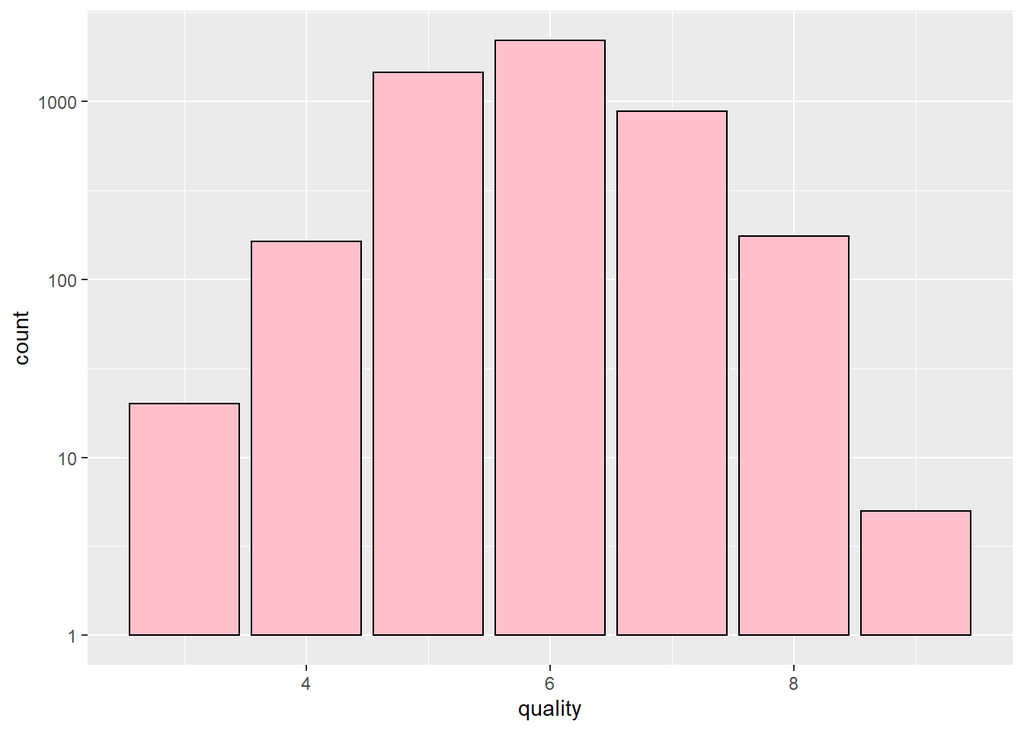

# Univariate Plots Section

*Note that we are most interested in ‘quality’ column as we want to see which variables help us find the best wine.

*It looks like Majority of our wines are quality between ‘5’ to ‘7’. There are less than 10 of the highest quality ‘9’ and dataset is normally distributed.

*Let’s look at some boring bar plots of rest of the variables.

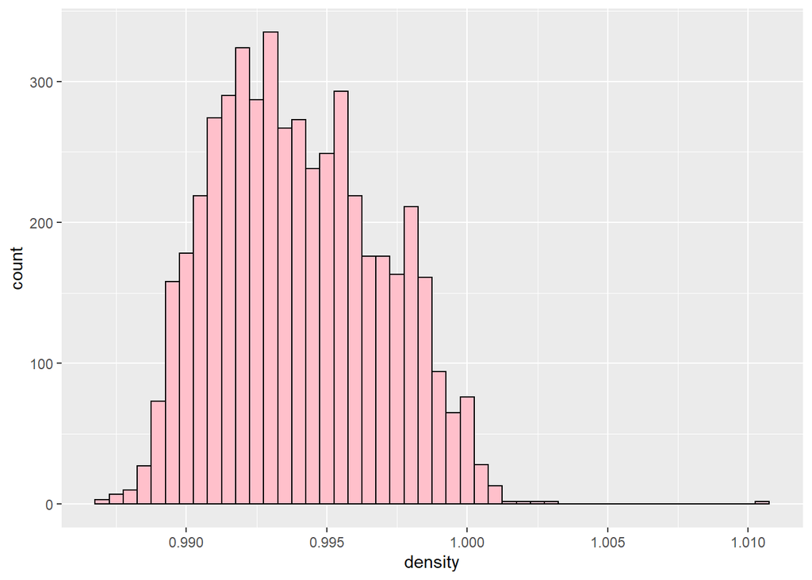

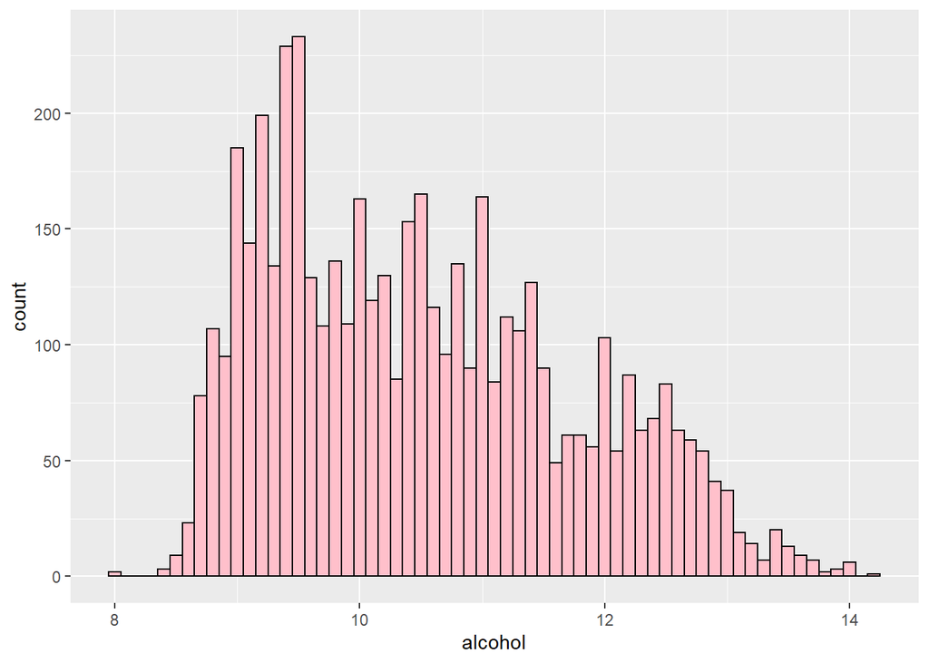

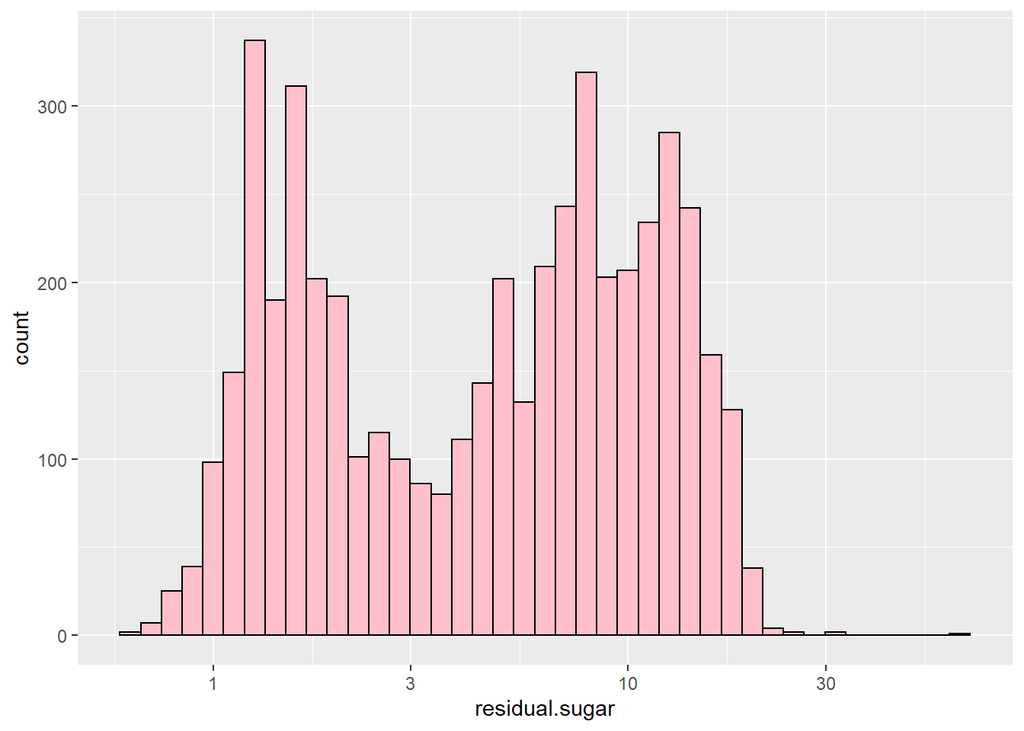

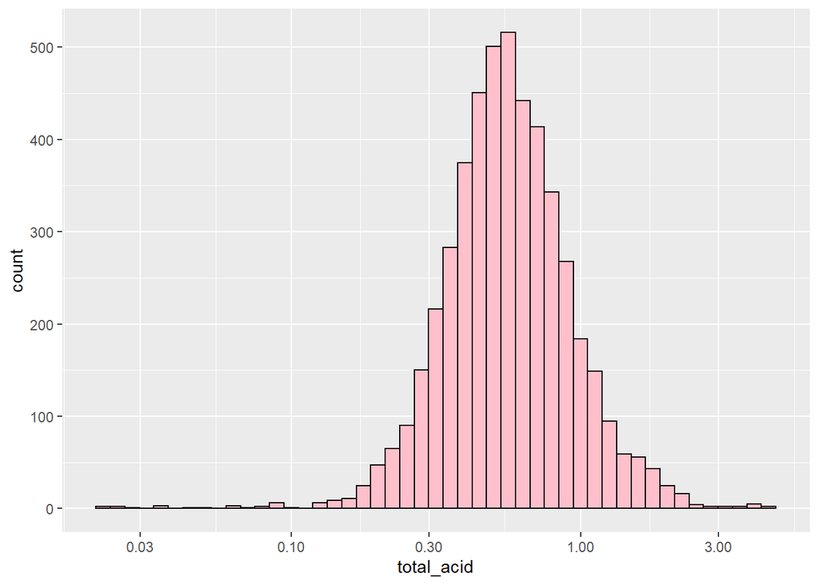

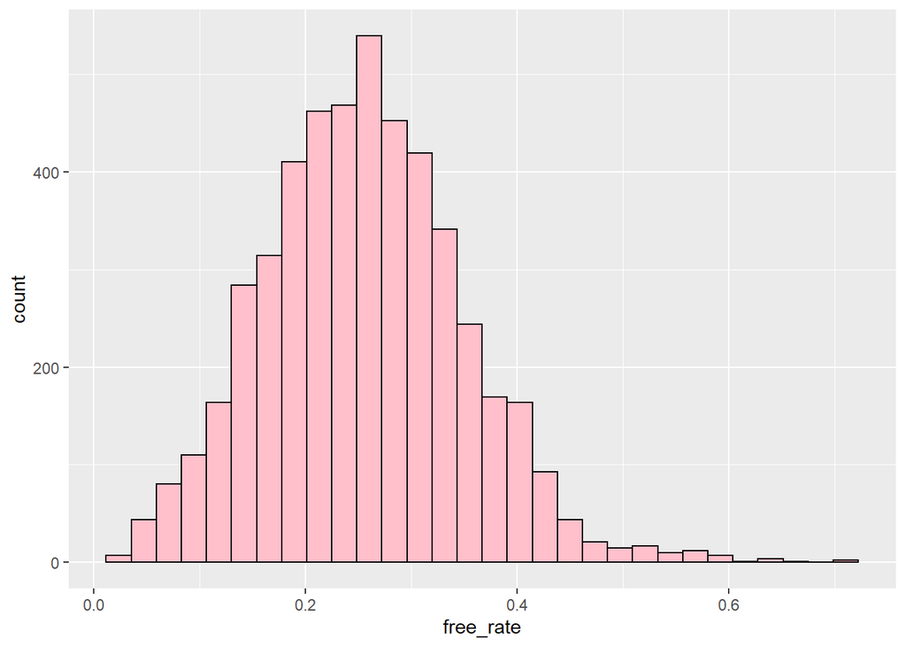

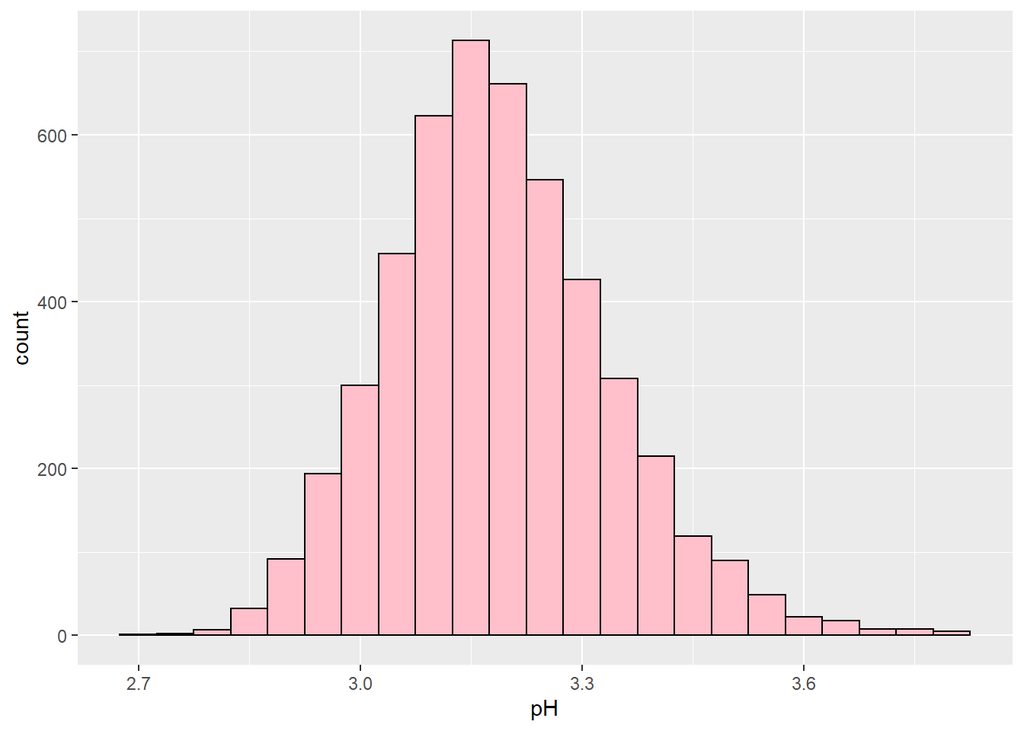

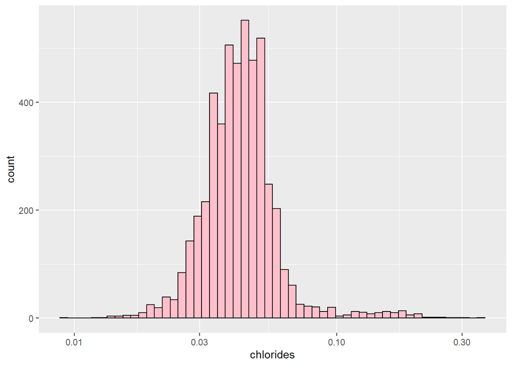

Boring as expected.

### Some interesting points:

- Since the dataset consists of real experts (human in the end), I think majority of their points comes from sweetness(sugar), acidity, alcohol and density.
- I’ve created total_acidity variable which doesn’t make any sense but simplifies fixed, volatile and citric acids and free_rate which is proportion of free sulfur dioxide in total sulfur dioxide. Both for small dimension reduction purpose.
- Sugar had two main peaks at around 2 and 10. I guess majority of winemakers like to make their wine either sweet or not sweet. Most datas were skewed due to very few extreme outliers.

# One shot look at all bivariates

```
## [1] "residual.sugar" "chlorides"      "density"        "pH"
## [5] "sulphates"      "alcohol"        "quality"        "total_acid"
## [9] "free_rate"
```

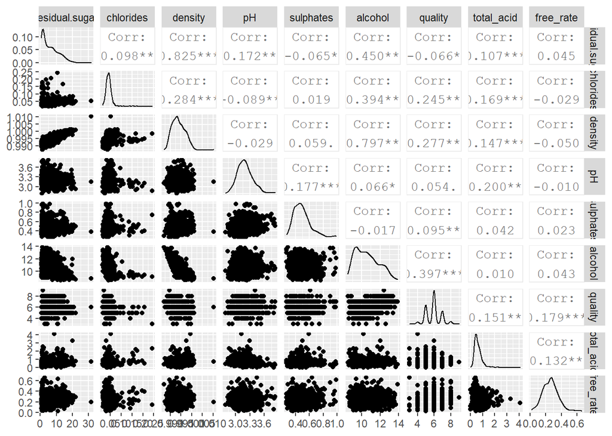

Let’s have a closer look.

```
## [1] "(2,4]" "(4,7]" "(7,9]"
```

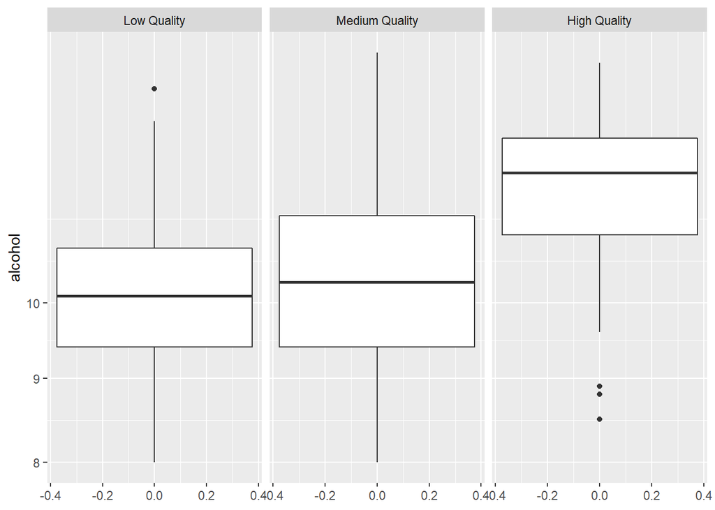

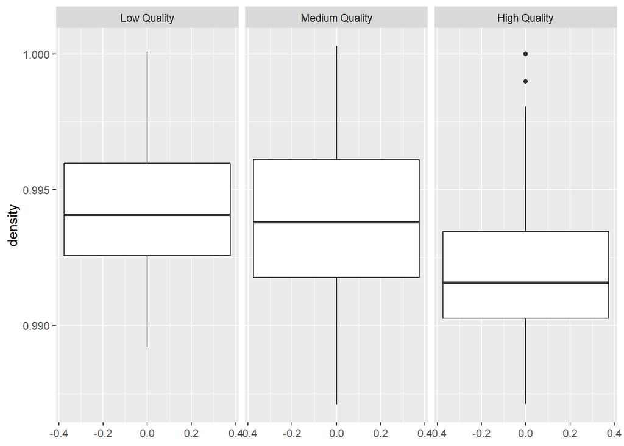

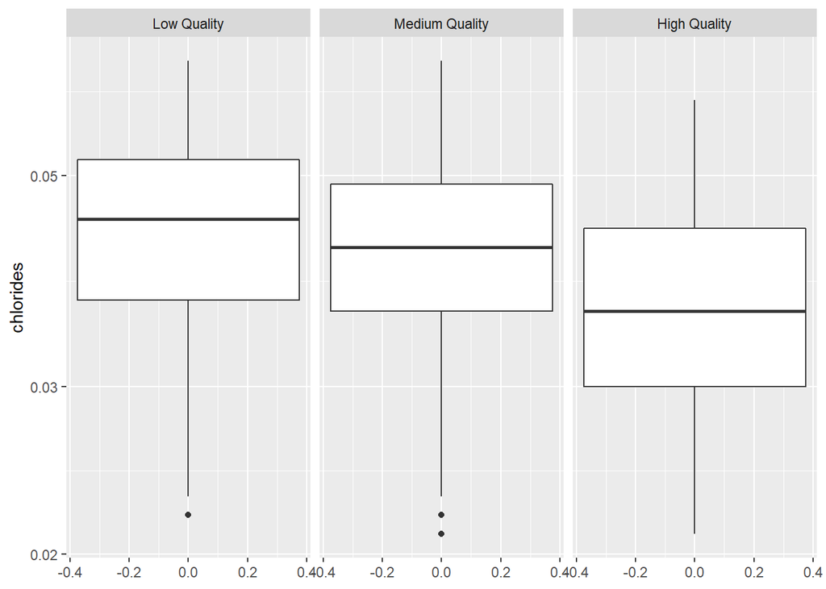

### Boxplots of different qualities

So clearly, high quality wines tend to have higher alcohol, lower density and lower chlorides than other qualities of wine.

| quality | med_alcohol | med_desity | med_chloride | n |
| --- | --- | --- | --- | --- |
| 3 | 10.45 | 0.994425 | 0.041 | 20 |
| 4 | 10.10 | 0.994100 | 0.046 | 163 |
| 5 | 9.50 | 0.995300 | 0.047 | 1457 |
| 6 | 10.50 | 0.993660 | 0.043 | 2198 |
| 7 | 11.40 | 0.991760 | 0.037 | 880 |
| 8 | 12.00 | 0.991640 | 0.036 | 175 |
| 9 | 12.50 | 0.990300 | 0.031 | 5 |

We used median here since most variables were severly skewed. We can somewhat guess typical characteristics of particular qualities in this chart. We can also see clear difference between quality 3 and 9 instantly.

# Multivariate Plots Section

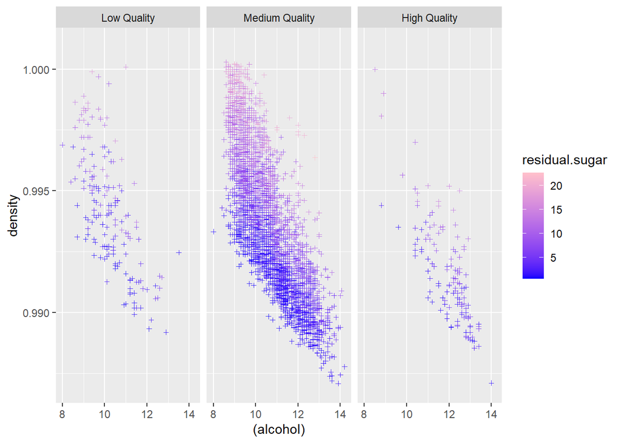

### Multivariate Section

There’s a lot going on here. First we can easily confirm that indeed density, alcohol and sugar closely related.

*2.* Alcohol and density are highly correlated. I suspect this is because alcohol is main source of reducing density since every other ingredients are likely to increase density.

*3.* High quality wines have a cluster at the higher alcohol and lower density quadrant. In contrast, low quality wines have a cluster located further towards 1st and 3rd quadrants. Medium quality wines covers both area.

*4.* No wines seem to exist lowest alcohol and lowest density region.

# Multivariate Linear Regression

```
##
## Call:
## lm(formula = quality ~ density + alcohol + chlorides, data = wine)
##
## Residuals:
##     Min      1Q  Median      3Q     Max
## -3.5904 -0.5209 -0.0050  0.4832  3.0653
##
## Coefficients:
##              Estimate Std. Error t value Pr(>|t|)
## (Intercept) -21.15016    6.16220  -3.432 0.000604 ***
## density      23.67087    6.07373   3.897 9.86e-05 ***
## alcohol       0.34312    0.01529  22.439  < 2e-16 ***
## chlorides    -2.38226    0.55760  -4.272 1.97e-05 ***
## ---
## Signif. codes:  0 '***' 0.001 '**' 0.01 '*' 0.05 '.' 0.1 ' ' 1
##
## Residual standard error: 0.7946 on 4894 degrees of freedom
## Multiple R-squared:  0.1955, Adjusted R-squared:  0.195
## F-statistic: 396.3 on 3 and 4894 DF,  p-value: < 2.2e-16
```

Of course this is just a old textbook solution. It is terrible and very time consuming to try different variable combinations. Lets use random forest instead.

# Random Forest Classifier on all quality [3,9]

[output not shown]

[output cut: 4888 more lines]

```
##
## Call:
##  randomForest(formula = factor(quality) ~ ., data = train, ntree = 500,      importance = TRUE)
##                Type of random forest: classification
##                      Number of trees: 500
## No. of variables tried at each split: 3
##
##         OOB estimate of  error rate: 31.73%
## Confusion matrix:
##   3  4   5    6   7  8 9 class.error
## 3 0  0   6    5   1  0 0   1.0000000
## 4 0 24  57   43   2  0 0   0.8095238
## 5 0  3 757  367  13  1 0   0.3365469
## 6 0  2 216 1440 103  2 0   0.1832104
## 7 0  0  12  314 391  3 0   0.4569444
## 8 0  0   2   45  41 63 0   0.5827815
## 9 0  0   0    2   3  0 0   1.0000000
```

# RFC(All quality) Interpretation (MeanDecreaseAccuracy, MeanDecreaseGini)

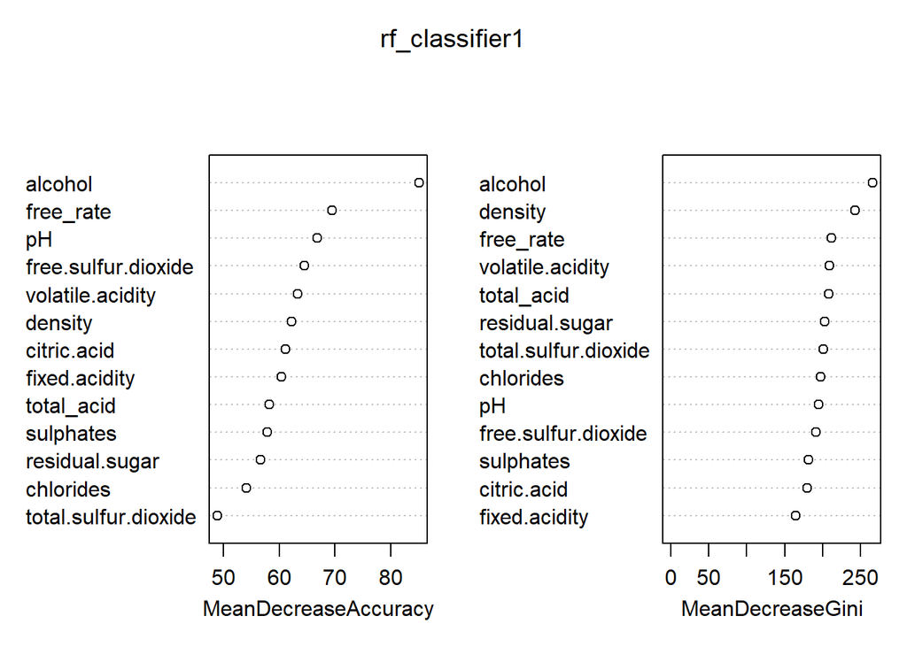

- To explain a little about the plots, MeanDecreaseAccuracy tells us how bad our predictions become if we were to omit that variable completly. MeanDecreaseGini tells us how clean the splits are if that variable was used to split the data.
- This had me wonder if I bucket some quality together into only 3 qualities, ‘High’, ‘Medium’, and ‘Low’ I should be able to increase accuracy by a significant amount.

# Random Forest Classifier on bucketed quality (High, Med, Low)

```
##
## Call:
##  randomForest(formula = factor(quality.bucket) ~ ., data = train,      ntree = 500, importance = TRUE)
##                Type of random forest: classification
##                      Number of trees: 500
## No. of variables tried at each split: 3
##
##         OOB estimate of  error rate: 5.59%
## Confusion matrix:
##            Low Qual. Med. Qual. High Qual. class.error
## Low Qual.         26        112          0 0.811594203
## Med. Qual.        11       3610          3 0.003863135
## High Qual.         0         93         63 0.596153846
```

# RFC(bucketed) Interpretation (MeanDecreaseAccuracy, MeanDecreaseGini)

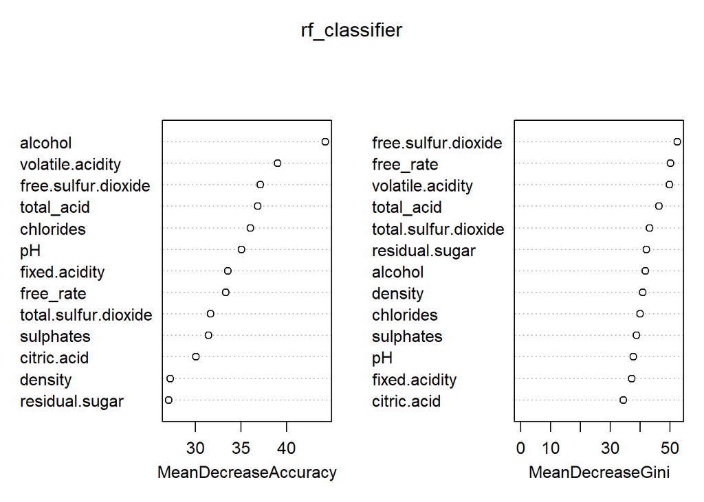

```
##             predicted
##              Low Qual. Med. Qual. High Qual.
##   Low Qual.          9         36          0
##   Med. Qual.         7        904          0
##   High Qual.         0         14         10
```

# RFC(bucketed) Interpretation 2 (ROC Curve)

### https://www.blopig.com/blog/2017/04/a-very-basic-introduction-to-random-forests-using-r/ (Reference)

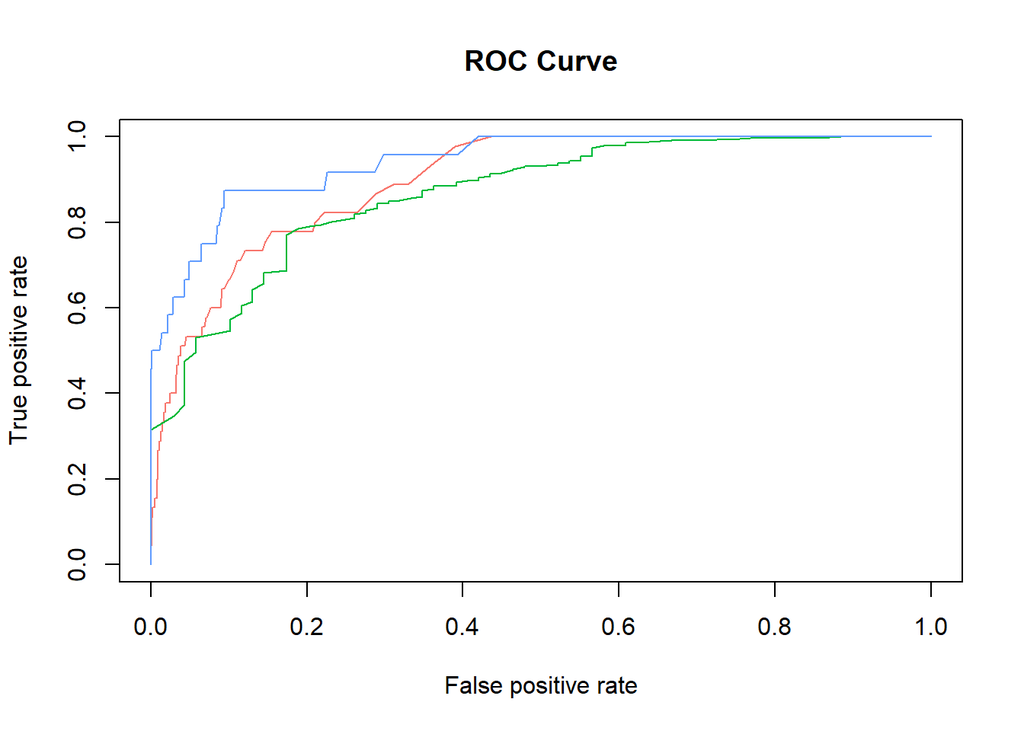

```
## [[1]]
## [1] 0.8978966
##
## [[1]]
## [1] 0.8655801
##
## [[1]]
## [1] 0.9413354
```

# Reflection

The white wine set contains information on almost 5000 wine data which all have been evaluated by at least 3 different wine experts. We explored many variables and predicted that since density, chlorides, and alcohol had high correlation, their combination will define the quality of any wine. We also looked at an interesting relationship between chemicals like sugar makes density go up and alcohol go down.

In conclusion, as predicted from my idea; acidity, sweetness, alcohol level but density plays a very important factor in determining high quality white wines. So although I’ve never had wine in my life, I can taste one and tell if it is good or not : )